# Cleaning US Influenza Admissions Data

From a raw surveillance CSV to a tidy, forecast-ready table

## What this script does, and why

Before we can *explore* or *model* respiratory data, we need a clean, predictable table to build on. Raw surveillance exports are rarely in the shape we want: they carry hundreds of columns we don’t need, mix geographies together, and store numbers as text.

This document walks through a small cleaning pipeline that takes the CDC weekly Hospital Respiratory Data (HRD) export and produces one tidy file: **one row per week** of **US** influenza admissions, with exactly three columns — `week`, `location`, and `value`. That three-column shape is deliberate: it matches the tidy layout the rest of our modeling and FluSight work expects downstream.

A theme to notice throughout: **we make our assumptions explicit and check them.** Nearly every block below either states what it expects or verifies that it got it. That habit is what turns a script you *hope* works into a script you can *trust*.

## Packages, checked before they’re loaded

We lean on three packages here. `readr` gives us fast, predictable CSV reading and writing with explicit control over column types. `dplyr` gives us the verbs (`filter`, `transmute`, `arrange`) that make the transformation readable. `ggplot2` draws the epicurve at the end.

Rather than assume they’re installed, we check first and stop with a helpful message if any are missing — so a fresh machine fails with “here’s what to install” instead of a cryptic error deep in the script.

```r
required_pkgs <- c("readr", "dplyr", "ggplot2")

# Which of the required packages can't R find?
missing_pkgs <- required_pkgs[!vapply(
  required_pkgs, requireNamespace, logical(1), quietly = TRUE
)]

# If any are missing, stop now and say exactly how to fix it.
if (length(missing_pkgs) > 0) {
  stop(
    "Missing required package(s): ", paste(missing_pkgs, collapse = ", "),
    ". Install with install.packages(c(",
    paste0('"', missing_pkgs, '"', collapse = ", "), ")).",
    call. = FALSE
  )
}

suppressPackageStartupMessages({
  library(readr)
  library(dplyr)
  library(ggplot2)
})
```

## Define file paths in one place

We name every file the script touches up front, rather than scattering paths through the code. This gives us a single source of truth: if the data moves or we rename an output, we change it once, here.

Notice the structure of the output paths — `output/data/01_cleaning/...` and `output/figures/01_cleaning/...`. Keeping each script’s outputs in a folder named after the script (`01_cleaning`) means results never collide and it’s always obvious which step produced which file.

```r
input_path  <- "data/Weekly Hospital Respiratory Data (HRD) Metrics by Jurisdiction.csv"
output_path <- "output/data/01_cleaning/cleaned_flu_admissions.csv"
figure_path <- "output/figures/01_cleaning/epicurve_us_flu_admissions.png"
```

> **Knitting note:** these are *relative* paths, so they assume your working directory is the project root (the folder that contains `data/`). When you knit an `.Rmd`, R uses the document’s own folder as the working directory by default, so if the knit can’t find the input file, that’s usually the reason.

Because we’d rather catch a bad path here than three chunks later, we confirm the input actually exists before doing anything with it.

```r
if (!file.exists(input_path)) {
  stop(
    "Input file not found: ", input_path,
    "\nSet the working directory to the project root (the folder containing ",
    "data/). Current working directory: ", getwd(),
    call. = FALSE
  )
}
```

## Create output folders if they don’t exist

A script shouldn’t assume its destination folders are already there. `dir.create` with `recursive = TRUE` builds the full folder tree, and `showWarnings = FALSE` keeps it quiet when the folders already exist (which is the normal case on a re-run). `dirname()` just strips the filename off, leaving the folder to create.

```r
dir.create(dirname(output_path), recursive = TRUE, showWarnings = FALSE)
dir.create(dirname(figure_path), recursive = TRUE, showWarnings = FALSE)
```

## Read only the columns we need

The raw export is wide — roughly 400 columns — but we only care about three things: the week, the geography, and the influenza admissions count. `col_select` pulls just those, which is faster and keeps our attention on what matters.

Two deliberate choices are worth calling out:

- **Read everything as character** (`col_types = cols(.default = col_character())`). It may feel odd to read numbers as text, but it means *we* decide when and how each column becomes a number — instead of letting `readr` guess from the first few rows and occasionally get it wrong on messy surveillance data. We convert on purpose in a later step.
- **`any_of(...)` for the admissions column.** Different exports of this dataset spell the column either `Total.Influenza.Admissions` (dots) or `Total Influenza Admissions` (spaces). `any_of()` will grab whichever one is present and silently ignore the other, so the read doesn’t break either way.

```r
raw <- read_csv(
  input_path,
  col_select = c(
    `Week Ending Date`,
    `Geographic aggregation`,
    any_of(c("Total.Influenza.Admissions", "Total Influenza Admissions"))
  ),
  col_types = cols(.default = col_character()),
  show_col_types = FALSE
)
```

## Figure out which spelling of the column we actually got

We handled *reading* either spelling above; now we need to know which one landed in `raw` so we can refer to it downstream. We check both candidate names against the columns that actually exist and keep the first match.

If neither is present, something is wrong with the input file, and we `stop()` immediately with a clear message rather than failing mysteriously three steps later. **Fail early, fail loudly, and say why** — future-you (or a classmate re-running this) will thank you.

```r
# Support both dotted and spaced versions of the influenza admissions column name.
influenza_col <- c("Total.Influenza.Admissions", "Total Influenza Admissions")
influenza_col <- influenza_col[influenza_col %in% names(raw)][1]

if (is.na(influenza_col)) {
  stop("Could not find influenza admissions column in input data.", call. = FALSE)
}
```

## Reshape into the tidy table we want

This is the heart of the script. Reading it as a pipeline, top to bottom:

- **`filter(...)`** keeps only the national (“USA”) rows, dropping every state and territory. This step is why our output is US-only.
- **`transmute(...)`** builds a brand-new set of columns and drops everything else (unlike `mutate`, which keeps the originals). We create exactly the three we want:
  - `week` — the `Week Ending Date` text turned into a real `Date`, so it sorts and plots correctly as time.
  - `location` — hard-coded to `"US"`, a stable label for the national series.
  - `value` — the admissions count. `parse_number()` pulls the numeric value out of the character column, tolerating comma-formatted counts such as `"1,110"`. `.data[[...]]` lets us reference the column by the *name we resolved* a moment ago, whichever spelling it turned out to be.
- **`arrange(week)`** sorts chronologically, so the series reads left-to-right in time — important for both the checks and the plot that follow.

```r
cleaned <- raw %>%
  filter(`Geographic aggregation` == "USA") %>%
  transmute(
    week = as.Date(`Week Ending Date`, format = "%Y-%m-%d"),
    location = "US",
    value = readr::parse_number(.data[[influenza_col]])
  ) %>%
  arrange(week)
```

## Take a look at the cleaned data

Before trusting anything, let’s actually *see* what we built. `dim()` reports the shape — how many weeks (rows) and columns we ended up with — and `head()` prints the first several rows so we can eyeball the values. Notice the column types shown under each name: `week` is a `date`, `location` is text (`chr`), and `value` is a number (`dbl`) — exactly the three-column, correctly-typed layout we were aiming for.

```r
dim(cleaned)      # number of weeks (rows) and columns
```

```
## [1] 307   3
```

```r
head(cleaned, 10) # first ten weeks of the cleaned series
```

```
## # A tibble: 10 × 3
##    week       location value
##    <date>     <chr>    <dbl>
##  1 2020-08-08 US           0
##  2 2020-08-15 US           0
##  3 2020-08-22 US           0
##  4 2020-08-29 US           0
##  5 2020-09-05 US           0
##  6 2020-09-12 US           0
##  7 2020-09-19 US           0
##  8 2020-09-26 US           0
##  9 2020-10-03 US           0
## 10 2020-10-10 US           0
```

## Check that the result is what we promised

Here we verify the cleaned table against a small contract we set for ourselves. Each `stop()` halts the script the moment a claim turns out to be false, so a bad result can never quietly slip into the next stage of the pipeline. We spell each check out separately, and phrase its failure message to say *exactly* what went wrong — a report that stops with “week contains 3 NA values after date parsing” is far easier to debug than a bare `FALSE`.

Read these as a checklist of everything we’re claiming about `cleaned`:

- at least one row survived the filter (we didn’t accidentally wipe everything out);
- the columns are *exactly* `week`, `location`, `value`, in that order;
- every row is US;
- `week` really is a `Date`, with no missing values from a bad parse;
- `value` really is numeric, with no missing values from a bad parse.

Writing checks like these is a genuinely useful habit: they’re an objective, machine-verifiable definition of “done” that the data has to satisfy before any later step is allowed to build on it.

```r
# There has to be something left after filtering to USA.
if (nrow(cleaned) == 0) {
  stop(
    "Validation failed: no rows remain after filtering to ",
    "`Geographic aggregation` == \"USA\".",
    call. = FALSE
  )
}

# The columns must be exactly week, location, value, in that order.
if (!identical(names(cleaned), c("week", "location", "value"))) {
  stop(
    "Validation failed: columns must be exactly week, location, value (in that ",
    "order). Found: ", paste(names(cleaned), collapse = ", "), ".",
    call. = FALSE
  )
}

# Every location label should read "US".
if (!all(cleaned$location == "US")) {
  stop(
    "Validation failed: every `location` value must be \"US\". Found: ",
    paste(unique(cleaned$location), collapse = ", "), ".",
    call. = FALSE
  )
}

# week must be a Date...
if (!inherits(cleaned$week, "Date")) {
  stop(
    "Validation failed: `week` must be a Date. Found class: ",
    paste(class(cleaned$week), collapse = "/"), ".",
    call. = FALSE
  )
}

# ...and every date must have parsed successfully.
if (any(is.na(cleaned$week))) {
  stop(
    "Validation failed: `week` contains ", sum(is.na(cleaned$week)),
    " NA value(s) after date parsing. Check the format of `Week Ending Date`.",
    call. = FALSE
  )
}

# value must be numeric...
if (!is.numeric(cleaned$value)) {
  stop(
    "Validation failed: `value` must be numeric. Found class: ",
    paste(class(cleaned$value), collapse = "/"), ".",
    call. = FALSE
  )
}

# ...and every count must have parsed successfully.
if (any(is.na(cleaned$value))) {
  stop(
    "Validation failed: `value` contains ", sum(is.na(cleaned$value)),
    " NA value(s) after parsing column `", influenza_col, "`.",
    call. = FALSE
  )
}
```

## Save the cleaned data

With the table validated, we write it out as a CSV — the artifact the next scripts will read. The final check confirms the file actually landed on disk, closing the loop on “did this step really succeed?”

```r
write_csv(cleaned, output_path)

if (!file.exists(output_path)) {
  stop("Validation failed: expected output CSV was not created at ", output_path, ".",
       call. = FALSE)
}
```

## Draw an epicurve as a visual sanity check

Numbers passing checks is one kind of confidence; *seeing* the data is another. A quick epidemic curve (an “epicurve”) — admissions plotted over time — instantly reveals whether the series has the seasonal flu shape we’d expect, or whether something looks off.

We build the plot once with `ggplot2` and use it twice: **render it inline** so you can see it right here in the knitted document, and **save a high-resolution copy to disk** (the version the pipeline and any report would use). A few details in this block:

- `geom_col()` draws one bar per week; the `#2C7FB8` blue and a fixed bar `width` keep it reading as a clean curve rather than a cluttered bar chart.
- `scale_x_date()` labels the time axis every six months, so a multi-season series stays legible.
- `theme_minimal()` strips the chart back to the data, and rotating the x-axis text keeps the date labels from colliding.

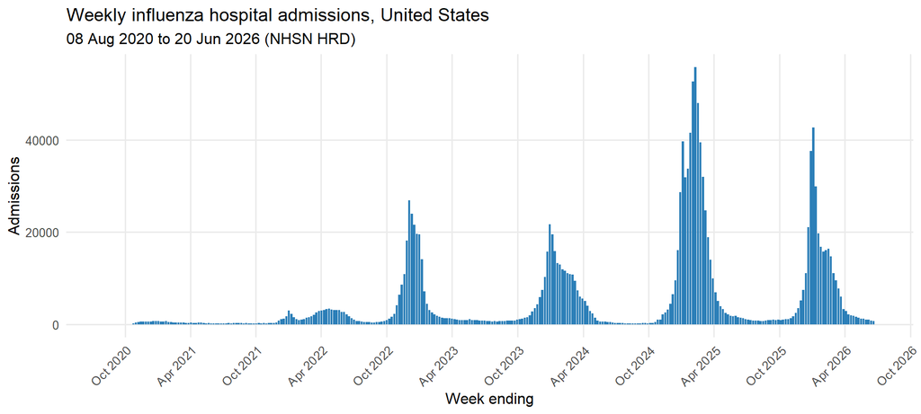

US weekly influenza admissions (NHSN HRD).

```r
epicurve <- ggplot(cleaned, aes(x = week, y = value)) +
  geom_col(fill = "#2C7FB8", width = 6) +
  scale_x_date(date_labels = "%b %Y", date_breaks = "6 months") +
  labs(
    title = "Weekly influenza hospital admissions, United States",
    subtitle = paste0(
      format(min(cleaned$week), "%d %b %Y"), " to ",
      format(max(cleaned$week), "%d %b %Y"), " (NHSN HRD)"
    ),
    x = "Week ending",
    y = "Admissions"
  ) +
  theme_minimal(base_size = 12) +
  theme(
    panel.grid.minor = element_blank(),
    axis.text.x = element_text(angle = 45, hjust = 1)
  )

# Show it in the knitted document...
epicurve
```

```r
# ...and save the same figure to disk for the pipeline to reuse.
ggsave(figure_path, plot = epicurve, width = 10, height = 4.5, dpi = 300)

if (!file.exists(figure_path)) {
  stop("Validation failed: expected epicurve was not created at ", figure_path, ".",
       call. = FALSE)
}
```

## Where this leads

We now have a small, trustworthy file — `cleaned_flu_admissions.csv` — plus a picture of the series. That clean table is the foundation for the next steps: exploring the data more deeply and, from there, fitting forecasting models. Every minute spent making this step reliable pays off in every step that builds on it.

```
## 01_cleaning complete.
##   Source column: Total Influenza Admissions
##   Rows written:  307
##   Date range:    2020-08-08 to 2026-06-20
##   Cleaned data:  output/data/01_cleaning/cleaned_flu_admissions.csv
##   Epicurve:      output/figures/01_cleaning/epicurve_us_flu_admissions.png
```